# FLicc user guide

Multi-gear length-interval catch-curve analysis in FLR

Henning Winker (FAO-NFI)

23 October 2026

# 1 FLicc: a framework for length-interval catch curves

FLicc fits **length-interval catch curves (ICC)**: equilibrium models that explain the length composition of the catch by growth, natural mortality, fishing mortality and selectivity, integrated over length intervals (bins). It brings the two main lines of length-based per-recruit assessment into one framework, built on FLR (Kell et al. 2007) and fitted with TMB (Kristensen et al. 2016):

- **fishblicc** (Medley 2025), whose formulation FLicc follows most closely: steady-state length-interval survival with individual Linf gamma-distributed around the von Bertalanffy mean, constant mortality within each length interval, several gears with their own selectivity (logistic, normal and double-sided normal), and a negative-binomial likelihood. FLicc’s `pop_model = "gamma"` with `obs_model = "nb"` reproduces this setup (Reproducing fishblicc); FLicc fits it by maximum likelihood in TMB instead of Bayesian estimation in Stan.
- **LBSPR** (Hordyk et al. 2015, 2016), whose growth-type-group (GTG) formulation is FLicc’s default population model (`pop_model = "gtg"`): Linf varies between growth-type groups, each with its own survival through the length classes, and status is expressed as the spawning potential ratio.
- **LBB** (Froese et al. 2018), the length-based Bayesian biomass estimator, which is nested in the GTG model: one growth type, one gear, each year fitted separately, with priors on Linf and M/K. `lbb_flicc()` sets FLicc up as LBB, and LBB’s status measure B/B0 (exploited biomass relative to unfished) is available for any FLicc fit as the exploitable potential ratio (EPR; Reproducing LBB).

Each of these tools is a configuration of FLicc:

| Tool | FLicc configuration |
| --- | --- |
| LBSPR | `pop_model = "gtg"` (`ngtg = 13`, `maxsd = 2`, CVL 0.1), `obs_model = "mn"`, Linf, M/k and CVL fixed, `by_year = TRUE` |
| LBB | `lbb_flicc()`: `pop_model = "gtg"` with `ngtg = 1`, `obs_model = "dm"` (fixed precision; `ess = 20000` matches LBB’s Dirichlet), priors on Linf and M/k, `by_year = TRUE`, `pile = 0` or `1` |
| fishblicc | `pop_model = "gamma"`, `obs_model = "nb"`, several gears, catch shares in numbers |
| FLicc default | `pop_model = "gtg"`, `obs_model = "dm"` with the precision estimated (`dm_theta = "saturating"`), all years jointly with a random walk on F |

Each configuration is reproduced on the tool’s own example data, and compared with FLicc’s default, in section Reproducing LBSPR, LBB and fishblicc.

On this common basis FLicc adds what a routine assessment and management procedure needs: several years fitted jointly with shared selectivity and a random walk on F, alternative observation models (multinomial, Dirichlet-multinomial with estimated precision, negative binomial), treatment of the tail of the composition, reference points with steepness, length-based indicators, residual diagnostics, and use as the estimation model of an MSE in FLR.

The names of the models and options in FLicc credit these sources: fishblicc for the length-interval catch-curve formulation, multi-gear selectivity and the gamma growth model; LBSPR for the GTG model and the SPR-based use of length data in data-limited fisheries; LBB for the single-growth-type special case, its priors and the B/B0 status measure.

## 1.1 About this guide

The guide is in three parts. **Part I** goes through an assessment from the data to stock status: length-frequency data (including missing data), life history, selectivity, fitting and diagnostics, reference points and status, and length-based indicators, with explicit **checks** at each step (what to look at, what is a red flag, what to do about it). **Part II** documents the technical options for users who need them: effective sample size and observation models, fishing mortality over time, growth variability and life-history priors, the tail of the composition, the model equations and a comparison of models, and the reproduction of LBSPR, LBB and fishblicc. **Part III** covers use in management-strategy evaluation and summarises the checks and recommendations. The examples use the built-in splendid alfonsino data. Recommendations marked *simulation* come from tests with an alfonsino-like operating model (fixed-CV length-at-age, annual recruitment, Beverton-Holt h = 0.75, two gears, two-stage length sampling). Monte-Carlo ensembles over life-history uncertainty (`mc_flicc()`) will be documented separately.

# 2 Installation

`FLicc` depends on `FLCore`, `ggplotFL` and `TMB`. On Windows, compiling the TMB model requires Rtools (https://cran.r-project.org/bin/windows/Rtools/).

```r
install.packages("TMB", type = "source")
install.packages(c("FLCore", "ggplotFL"),
                 repos = c("https://flr.r-universe.dev", "https://cloud.r-project.org"))
remotes::install_github("henning-winker/FLicc")                    # release
remotes::install_github("henning-winker/FLicc", ref = "dev-merge")  # development
```

```r
library(FLicc)
packageVersion("FLicc")
```

```
#> [1] '1.0.11'
```

# 3 Quick start: your first fit

This section goes from a table of length measurements to a first fitted model and its main plots, using the default settings. The later sections explain each step, the checks to make and the options.

## 3.1 Step 1: length data as a table

FLicc needs length-frequency counts by **length bin**, **year** and **gear** (fleet). The simplest starting point is a long table with one row per bin, year and gear, and the columns `len` (lower bound of the length bin), `year`, `data` (number of fish measured) and `qname` (gear name). The alfonsino example data in this format:

```r
library(FLicc)
data("alfonsino")
lfd_df <- as.data.frame(lfd_alfonsino)[, c("len", "year", "data", "qname")]
head(lfd_df)
```

```
#>   len year data qname
#> 1   5 2013    0 Trawl
#> 2   6 2013    0 Trawl
#> 3   7 2013    0 Trawl
#> 4   8 2013    0 Trawl
#> 5   9 2013    0 Trawl
#> 6  10 2013    0 Trawl
```

```r
unique(lfd_df$qname)       # gears
```

```
#> [1] Trawl   Gillnet
#> Levels: Trawl Gillnet
```

```r
range(lfd_df$len)          # length range (cm)
```

```
#> [1]  5 67
```

```r
range(lfd_df$year)         # years
```

```
#> [1] 2013 2024
```

For your own data, read the file and name the columns accordingly, for example:

```r
lfd_df <- read.csv("my_length_data.csv")              # columns: length, year, count, fleet
names(lfd_df) <- c("len", "year", "data", "qname")
```

## 3.2 Step 2: convert to `FLQuants`

`lfd_long_to_wide()` turns the long table into a wide one (one column per year, missing combinations filled with zeros), and `FLQuantLen()` turns that into an `FLQuants` object with one `FLQuant` per gear. `midL = FALSE` says that `len` is the lower bound of each bin; use `midL = TRUE` if your lengths are bin mid-points. Lengths in mm can be converted with `unit = "mm"`.

```r
lfd <- FLQuantLen(lfd_long_to_wide(lfd_df), unit = "cm", midL = FALSE)
names(lfd)
```

```
#> [1] "Trawl"   "Gillnet"
```

## 3.3 Step 3: look at the data

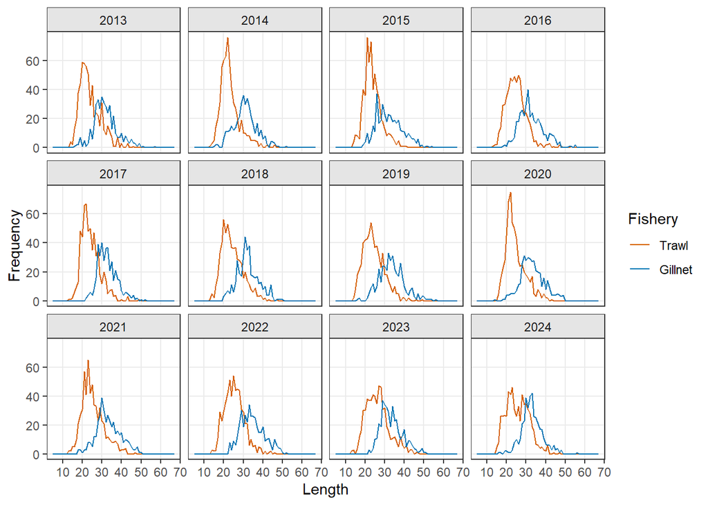

```r
plot_lfd(lfd)
```

Each panel is a year, each colour a gear. Check that the compositions look plausible: one main mode per gear, no sudden shifts between years, no fish far beyond the expected maximum length.

## 3.4 Step 4: life history

Growth, natural mortality, maturity and the length-weight relationship are given as an `FLPar`:

| Parameter | Meaning |
| --- | --- |
| `linf`, `k` | von Bertalanffy asymptotic length and growth rate |
| `M` | natural mortality (per year) |
| `L50` | length at 50% maturity |
| `a`, `b` | weight-length relationship $W = aL^b$ (here weight in kg for length in cm) |

```r
lhpar <- FLPar(linf = 55.7, k = 0.08, M = 0.162, L50 = 31.1859,
               a = 0.004721956 / 1000, b = 3.146168)
```

## 3.5 Step 5: the stock object and natural mortality

`stocklen()` combines the length data and the life history into an `FLStockLen` object with weight, maturity and natural mortality at length. `m_model` sets how natural mortality changes with length:

| `m_model` | M at length |
| --- | --- |
| `"constant"` | the same M at all lengths (default choice) |
| `"inverse"` | $M\,L_{ref}/L$, higher for small fish; needs `reflen` |
| `"Lorenzen"` | allometric, decreasing with weight |
| `"Gislason"` | empirical, depending on length and Linf |

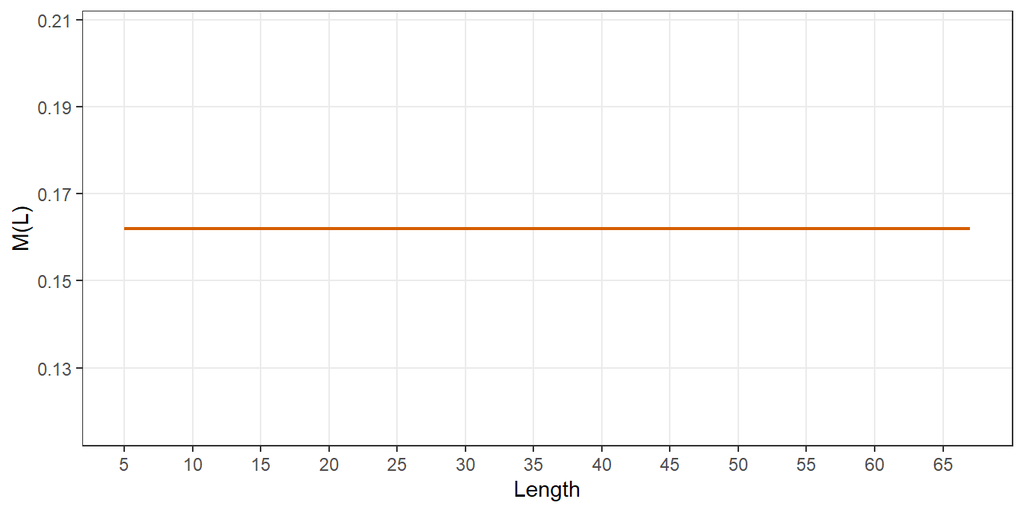

```r
stklen <- stocklen(lfd, lhpar, m_model = "constant")
plot_m(stklen)
```

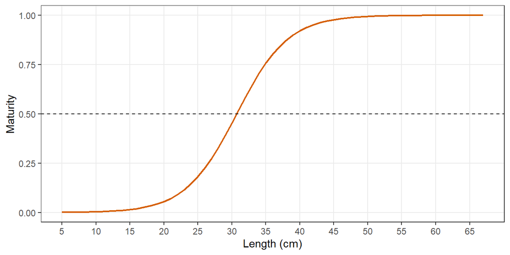

```r
plot_mat(stklen)
```

Start with `"constant"` unless there is a biological reason for a length-dependent M.

## 3.6 Step 6: fit the model

Two inputs are always needed besides the data and the stock object, both with one entry per gear in the order of `names(lfd)` (here Trawl, Gillnet):

- **`sel_fun`**: the shape of each gear’s selectivity. `"logistic"` for gears that keep catching the largest fish (asymptotic, e.g. most trawls and longlines); `"dsnormal"` (double-sided normal) for gears that catch mostly intermediate sizes and fewer large fish (dome-shaped, e.g. gillnets with one mesh size, or fleets fishing where large fish are scarce). Here the trawl catches small fish and few large ones, the gillnet the larger fish.
- **`catch_by_gear`**: the share of the total catch taken by each gear, e.g. `c(0.95, 0.05)` for 95% and 5%. It tells the model how to split F between the gears; FLicc matches it to the predicted catch **in weight**, so the shares of the landings in tonnes can be used directly.

```r
fit1 <- fiticc(lfd, stklen,
               sel_fun = c("dsnormal", "logistic"),
               catch_by_gear = c(0.95, 0.05))
```

All other settings are at their defaults: growth and M fixed at the input values, a Dirichlet-multinomial likelihood on the counts as they are, with its precision estimated from the data (so the counts need no rescaling), and a random walk on F over the years.

## 3.7 Step 7: check and plot the results

First check that the fit converged: all lines should show `passed = TRUE`.

```r
flicc_convergence(fit1)
```

```
#>                              check              value passed
#> 2           Gradient is acceptable          5.704e-05   TRUE
#> 3     Hessian is positive definite               TRUE   TRUE
#> 4        Standard errors available 31 / 31 parameters   TRUE
#> 5 Hessian eigenvalues are positive              14.22   TRUE
#> 6   Newton decrement is negligible           2.38e-13   TRUE
#> 7                          Overall                 ok   TRUE
#>                                                                                        interpretation
#> 2                                                             The fit is close to a stationary point.
#> 3                                                                The model curvature is well behaved.
#> 4                                                  Uncertainty could be estimated for all parameters.
#> 5                                             No flat or negative curvature directions were detected.
#> 6 Expected further gain in log-likelihood (0.5 g'H^-1 g) is below 0.001; NA without Newton polishing.
#> 7              ok: converged; warning: usable, but check the gradient or decrement; fail: do not use.
```

The fitted (lines) against the observed (bars) length compositions

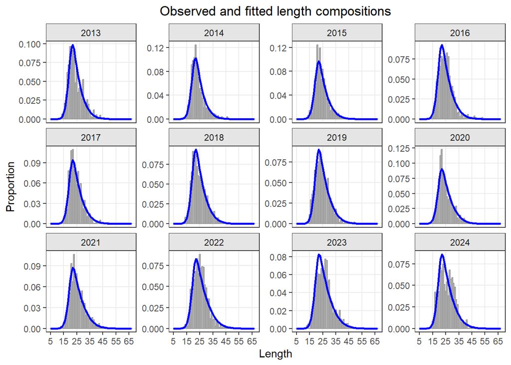

```r
plot_len(fit1)
```

also shown by gear

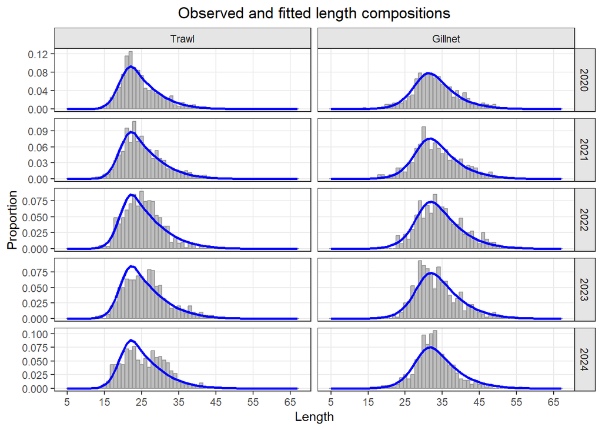

```r
plot_len(fit1, by_gear = TRUE,year=2020:2024)
```

The estimated selectivity of each gear:

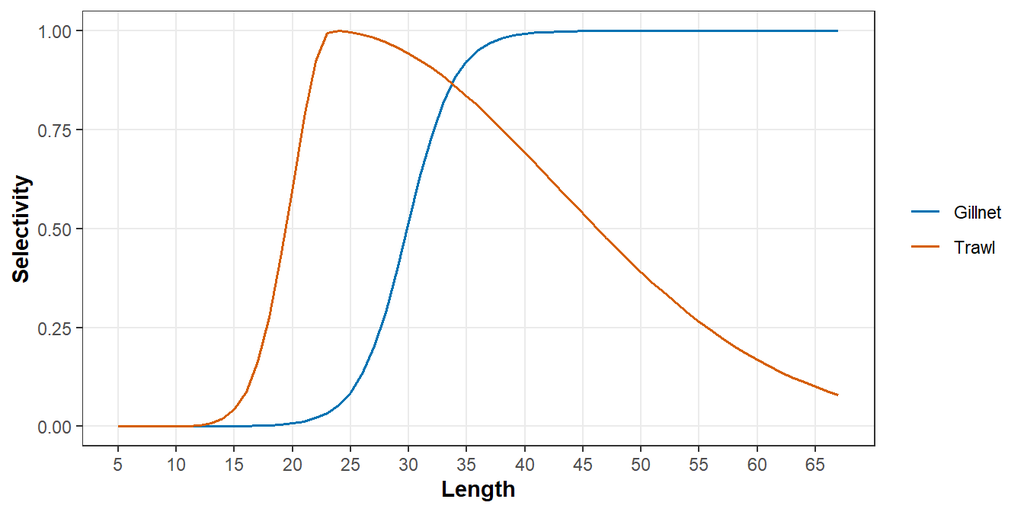

```r
plot_sel(fit1)
```

The spawning potential ratio (SPR) by year with its 95% interval, and the value in the last year. SPR is the spawning output per recruit at the estimated F relative to the unfished state; 40% is a common target.

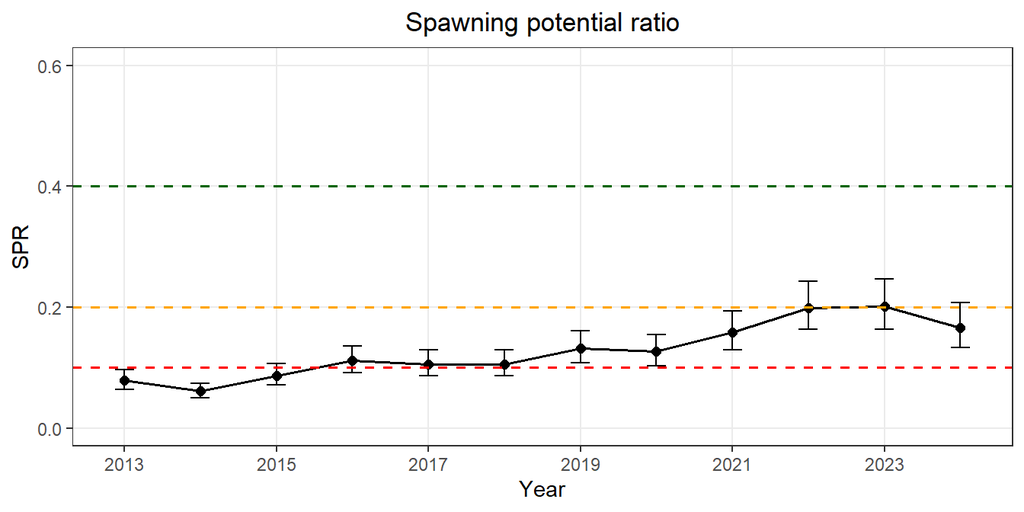

```r
plot_spr(fit1, ci = TRUE)
```

```r
sprcur_flicc(fit1)
```

```
#> [1] 0.1660614
```

That is a first assessment. Before using it, work through the checks of the following sections. The default likelihood estimates how much weight the length data can carry (section *Effective sample size and observation models*); it works best with the raw counts, as here, or an effective sample size of at least 500 per gear and year. The reference fit used in the rest of this guide (next section) is this default configuration.

# 4 Workflow and defaults

1. **Data**: length frequencies by gear as `FLQuants` (Quick start); check sample sizes, gaps and the tail.
2. **Life history**: `FLPar` and `stocklen()`; check Linf against the largest fish.
3. **Selectivity**: choose the shape per gear; dome sensitivity.
4. **Fit**: `fiticc()`; check convergence, residuals, selectivity and retrospective consistency.
5. **Status**: SPR, Fspr, steepness-corrected biomass, length-based indicators.
6. **Uncertainty**: sensitivity runs (selectivity dome, CVL, Linf, tail cut), `fits_summary()` and `ensemble_flicc()`.
7. **Management**: `flicc.sa()` and harvest control rules in an MSE.

A plain `fiticc()` call uses the GTG population model, a Dirichlet-multinomial likelihood with the precision estimated from the data, fixed growth (Linf, CVL) and natural mortality, and a random walk on log F with its standard deviation fixed at `sigmaF = 0.3`. Give it the raw counts or an effective sample size of at least 500 per gear and year. Every other option is a deliberate change.

## 4.1 The reference fit

The rest of the guide uses one reference fit of the alfonsino data: the raw counts, a double-sided normal (dome) selectivity for the trawl and a logistic one for the gillnet, catch shares of 95% and 5% by weight, CVL = 0.1, and the default Dirichlet-multinomial likelihood with the precision estimated from the data (`dm_theta = "saturating"`, section *Effective sample size and observation models*; given explicitly below for clarity).

```r
sel_fun <- c("dsnormal", "logistic")
cbg <- c(0.95, 0.05)
fit <- fiticc(lfd, stklen, sel_fun = sel_fun, catch_by_gear = cbg,
              settings = list(CVL = 0.1, obs_model = "dm", dm_theta = "saturating"))
sprcur_flicc(fit)
```

```
#> [1] 0.1660614
```

# Part I: Assessment basics

# 5 Length-frequency data

## 5.1 Structure

```r
data("alfonsino")
lfd <- FLQuantLen(lfd_long_to_wide(as.data.frame(lfd_alfonsino)), unit = "cm", midL = FALSE)
names(lfd)
```

```
#> [1] "Trawl"   "Gillnet"
```

```r
range(as.numeric(dimnames(lfd[[1]])$len)); range(as.numeric(dimnames(lfd[[1]])$year))
```

```
#> [1]  5 67
#> [1] 2013 2024
```

`FLQuantLen()` takes a wide table (`lfd_long_to_wide()` converts a long one) with columns for length, year, gear and counts; `midL = FALSE` means lengths are lower bin boundaries. Bins must be equally spaced and identical across gears and years (`complete_lfd_bins()` fills gaps with zeros).

## 5.2 Check 1: sample size by year and gear

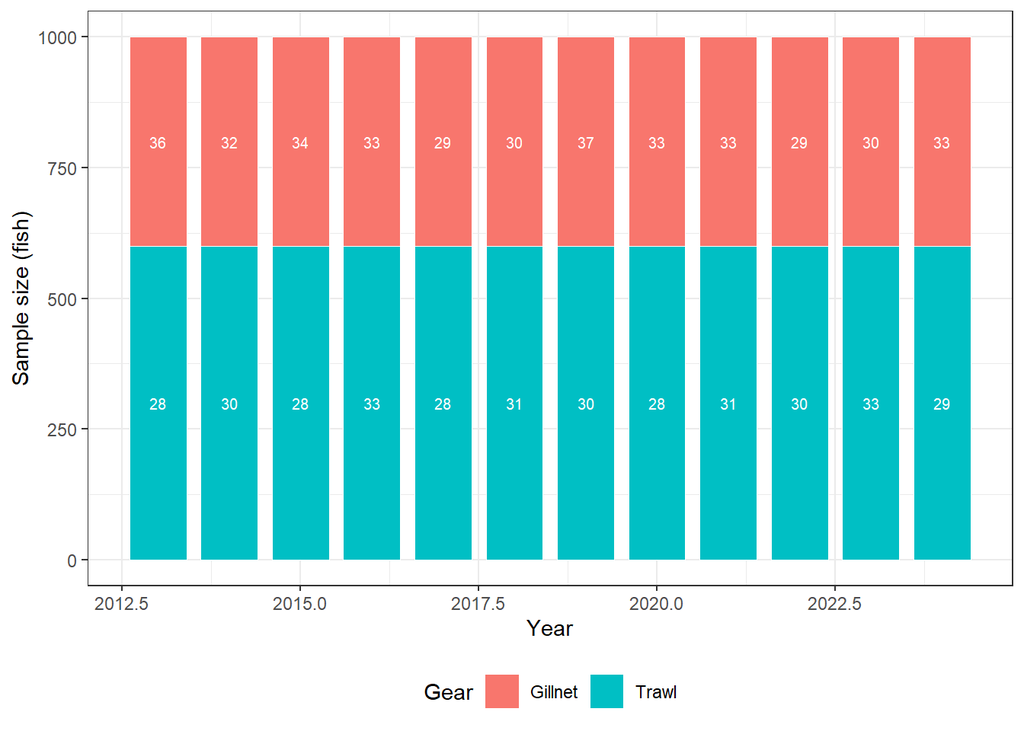

[output not shown]

```r
plot_lfdn(lfd)
```

## 5.3 Check 2: consistency of the compositions

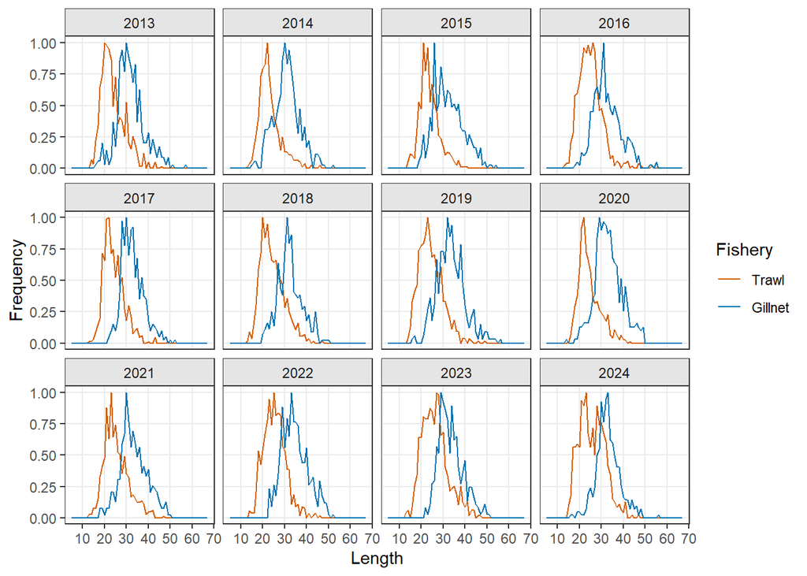

| **Look for** | Stable shapes and modes between adjacent years; similar left limbs within a gear (selectivity is assumed constant over time). |
| --- | --- |
| **Red flags** | Abrupt shifts in the mode or left limb (change of gear, mesh, market sorting or sampling programme); bimodal compositions from mixing gears or areas; truncation at the right (size limits, sorting). |
| **Action** | Split gears or periods with different selectivity; restrict `years`; investigate sampling before modelling around it. |

```r
plot_lfd(lfd, type = "relmax")
```

## 5.4 Check 3: the largest fish

```r
linf_in <- 55.7
sapply(lfd, function(x) {
  L <- as.numeric(dimnames(x)$len); n <- apply(x@.Data, 1, sum)
  c(max_length = max(L[n > 0]), pct_ge_0.9Linf = round(100 * sum(n[L >= 0.9 * linf_in]) / sum(n), 1),
    pct_ge_Linf = round(100 * sum(n[L >= linf_in]) / sum(n), 2))
})
```

```
#>                Trawl Gillnet
#> max_length        53   57.00
#> pct_ge_0.9Linf     0    0.40
#> pct_ge_Linf        0    0.06
```

| **Why** | The tail is the part of the composition most sensitive to Linf, CVL, dome-shaped selectivity and the GTG discretisation. |
| --- | --- |
| **Red flags** | More than about 1% of fish at or above the input Linf; a long thin tail far beyond Linf (misidentified species, measurement errors, other stocks). |
| **Action** | Re-examine Linf; use a tail cut (section *Tail of the length composition*) or `rob_eps`; `fiticc()` warns about fish beyond the largest growth group (`tail_warning`, default `TRUE`). |

## 5.5 Check 4: empirical catch curves

A log-linear catch curve on the length-converted ages gives a quick, model-free view of total mortality by year and of its trend:

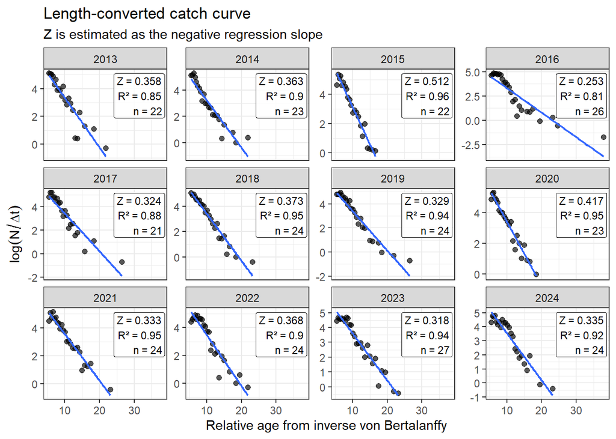

```r
lhpar <- FLPar(linf = 55.7, k = 0.08, M = 0.162, L50 = 31.1859,
               a = 0.004721956 / 1000, b = 3.146168)
plot_zlcc(lfd$Trawl, lhpar)
```

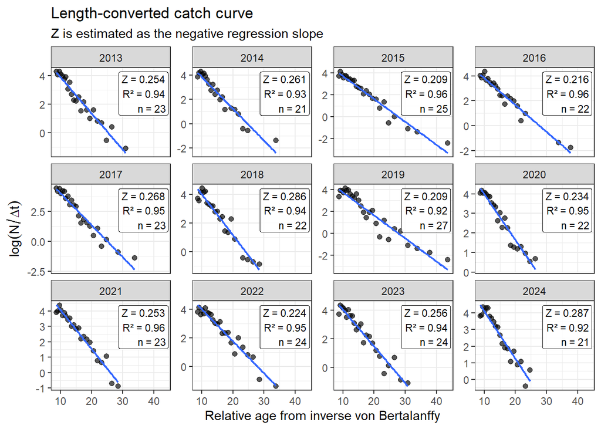

| **Look for** | Roughly linear descending limbs; a stable or smoothly changing slope (Z). |
| --- | --- |
| **Red flags** | Strongly curved descending limbs (dome-shaped selectivity, recruitment pulses), slopes jumping between years (sampling noise or changing selectivity). |
| **Action** | Consider `dsnormal` selectivity or a tail cut; expect noisy annual F and keep the random walk. |

```r
plot_zlcc(lfd$Gillnet, lhpar)
```

## 5.6 Missing data

```r
lfd_miss <- lfd
lfd_miss[["Gillnet"]][, c("2016", "2017","2022")] <- 0
lfd_miss[["Trawl"]][, c("2020","2022")] <- 0
fit_miss <- fiticc(lfd_miss, stklen, sel_fun = sel_fun, catch_by_gear = cbg,
                   settings = list(CVL = 0.1, obs_model = "dm", dm_theta = "saturating"))
flicc_convergence(fit_miss)
```

```
#>                              check              value passed
#> 2           Gradient is acceptable          1.799e-05   TRUE
#> 3     Hessian is positive definite               TRUE   TRUE
#> 4        Standard errors available 31 / 31 parameters   TRUE
#> 5 Hessian eigenvalues are positive              10.32   TRUE
#> 6   Newton decrement is negligible           1.29e-13   TRUE
#> 7                          Overall                 ok   TRUE
#>                                                                                        interpretation
#> 2                                                             The fit is close to a stationary point.
#> 3                                                                The model curvature is well behaved.
#> 4                                                  Uncertainty could be estimated for all parameters.
#> 5                                             No flat or negative curvature directions were detected.
#> 6 Expected further gain in log-likelihood (0.5 g'H^-1 g) is below 0.001; NA without Newton polishing.
#> 7              ok: converged; warning: usable, but check the gradient or decrement; fail: do not use.
```

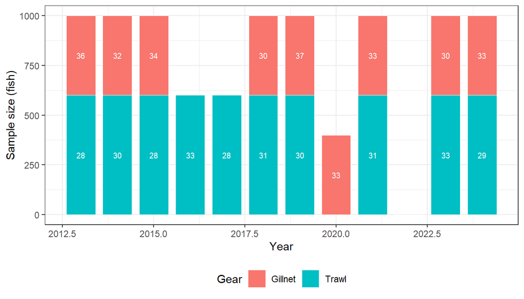

```r
plot_lfdn(lfd_miss)
```

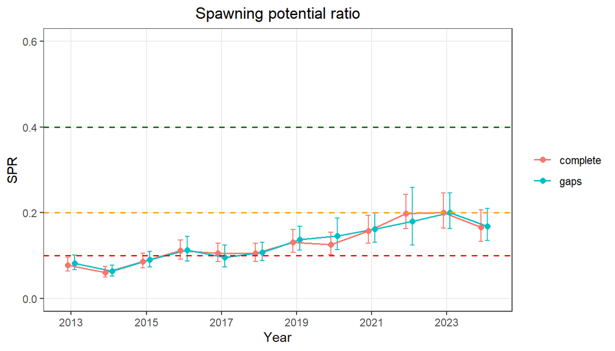

```r
plot_spr(list(complete = fit, gaps = fit_miss), ci = TRUE)
```

Guidelines:

| Situation | Handling |
| --- | --- |
| a gear missing in some years | keep the zeros; the random walk bridges them (intervals widen) |
| all gears missing in a year | leave the year in (F interpolated) or restrict `years` |
| long gaps or a gear only at the start or end | consider fitting the gear’s period separately; selectivity is assumed constant |
| no random walk (`prior_sigmaF = FALSE`) | **avoid with gaps**: F of a gear-year without data is not identified |
| `by_year = TRUE` | fits only years with data; selectivity per year |
| catch by gear missing | use the average split; it only enters through the catch-share constraint |

# 6 Life history and the stock object

```r
stklen
```

```
#> An object of class "FLStockLen"
#>
#> Name: FLicc stocklen
#> Description:
#> Quant: len
#> Dims:  len   year    unit    season  area    iter
#>  63  12  1   1   1   1
#>
#> Range:  min  max minyear maxyear minfbar maxfbar
#>  5   67  2013    2024    5   67
```

`stocklen(lfd, lhpar, m_model)` builds the length-based stock object: weight $W(L) = aL^b$, maturity as a logistic ogive with `L50` and `L95` (default `L95 = L50 + 0.2 Linf`), and natural mortality at length:

| `m_model` | $M(L)$ |
| --- | --- |
| `"constant"` | $M$ |
| `"inverse"` | $M\, L_{ref}/L$ |
| `"Lorenzen"` | Lorenzen weight-based, scaled to $M$ at `reflen` |
| `"Gislason"` | Gislason et al. (2010) from $L$, $L_\infty$, $k$ |

The length model uses $M/k$ (and $Z/k$): what matters is the ratio, so k and M uncertainty should be considered jointly (as in `mc_flicc()`).

## 6.1 Check 5: life-history inputs

| **Look for** | Linf close to the largest regularly observed lengths (Check 3); M/k near the life-history invariant range (often 1-2); L50 below the modal length of the main gear. |
| --- | --- |
| **Red flags** | Linf well below the largest fish (many fish beyond Linf) or far above it; Linf from another region or sex; M/k outside 0.5-3 without justification. |
| **Action** | Linf is the dominant sensitivity (simulation: a 10% error shifts SPR by +75% / -30%); run Linf sensitivities and include Linf in the ensemble. |

### 6.1.1 Growth and the growth-type groups

`plot_growth()` draws the growth curves of the growth-type groups the model uses (as in Fig. 1 of Hordyk et al. 2015), with Linf, the Linf of the largest group (no fish in the model grows beyond it), L50 and the largest observed fish of each gear. It needs only the life history and the GTG settings, so it is a check **before** the fit: the largest fish should lie below the largest group. `composition = TRUE` adds the unfished length composition of each group on the same length axis:

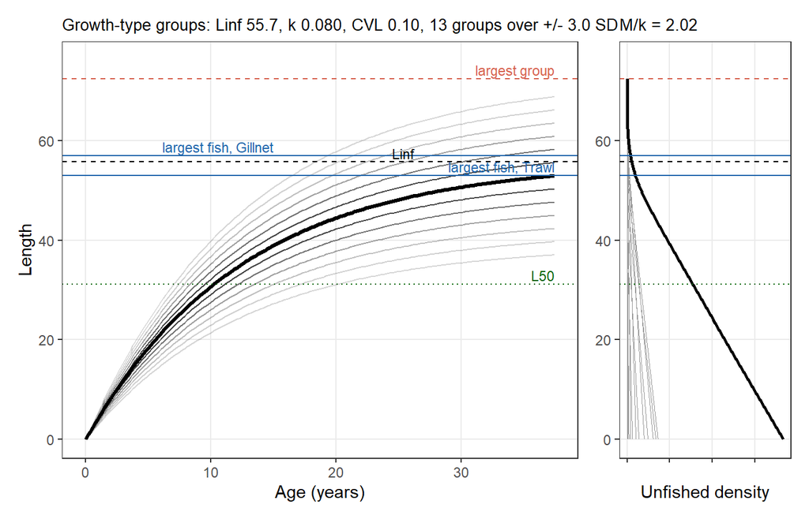

```r
plot_growth(lhpar, CVL = 0.1, lfd = lfd, composition = TRUE)
```

After a fit, `plot_growth(fit)` shows the groups of the fitted model (with the estimated Linf and CVL when `linf.sd` or `CVL.sd` are used).

### 6.1.2 Cohort modes and t0

FLicc does not need t0: it works in length, and t0 only shifts the age axis. But the length compositions can say something about growth when year classes show as modes. `growth_phase_flicc()` fits each composition as a mixture of age components whose mean lengths follow the growth curve, $\mu_j = L_\infty(1 - e^{-k(j + \phi)})$, with widths from the growth-type groups ($\mathrm{CVL}\,\mu_j$, plus a small extra spread `sd0`), as in MULTIFAN (Fournier et al. 1990). The weights of the components are free in each composition, so year-class strength and selectivity do not matter; only the positions and widths of the modes have to fit. The phase $\phi$ is common to all years and gears and is profiled:

- a clear maximum of the profile means that the modes follow the growth curve;
- a flat profile means that the compositions carry no information on the phase: the annual growth increment $(L_\infty - L)(1 - e^{-k})$ is small compared with the spread of length at age, so neighbouring year classes overlap;
- a vector of `k` gives a joint profile over phase and k, a check of the growth rate (with Linf fixed).

With the samples taken $\tau$ years after spawning (`sample - spawn`, as fractions of the year), $t_0 = \tau - \phi - m$. The integer $m$ (is the first mode age 0 or age 1?) is not identified by lengths alone; `$t0` lists the candidates with the implied lengths at age 1 and 2, to be chosen with knowledge of the biology. `age_first` is the true age of the first age component under each candidate (negative: that component is not yet born and the first mode is the next one), and `phase_interval` the approximate 95% interval of the phase (`NA` when the profile is flat). This is also the information needed for growth in age-based models (e.g. the length at a minimum age and the CV of young fish in SS3).

```r
gph <- growth_phase_flicc(fit, spawn = 0, sample = 0.5)   # spawning at the start, sampling mid-year
gph$best
```

```
#>       k phase    logLik dLL
#> 15 0.08  0.28 -14786.47   0
```

```r
gph$t0
```

```
#>    m age_first    t0 t0_lwr t0_upr L_age1 L_age2
#> 1 -1       1.5  1.22     NA     NA  -0.99   3.37
#> 2  0       0.5  0.22     NA     NA   3.37   7.39
#> 3  1      -0.5 -0.78     NA     NA   7.39  11.11
#> 4  2      -1.5 -1.78     NA     NA  11.11  14.54
```

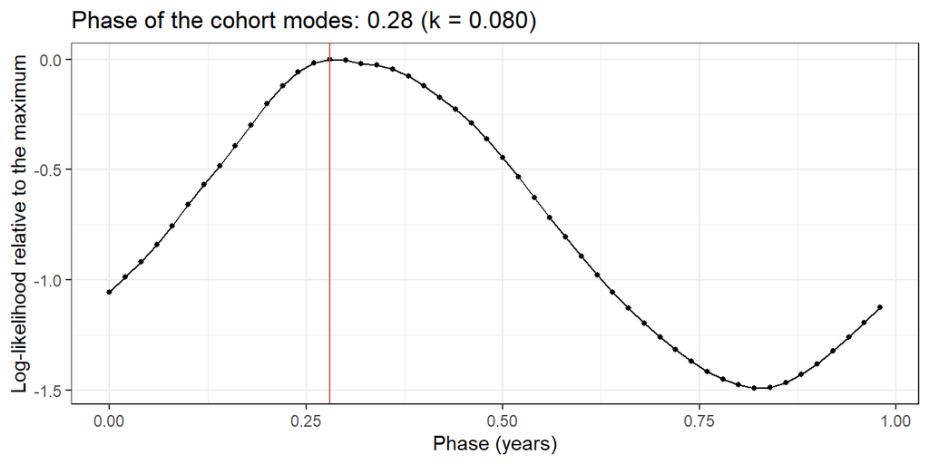

```r
plot_growth_phase(gph)
```

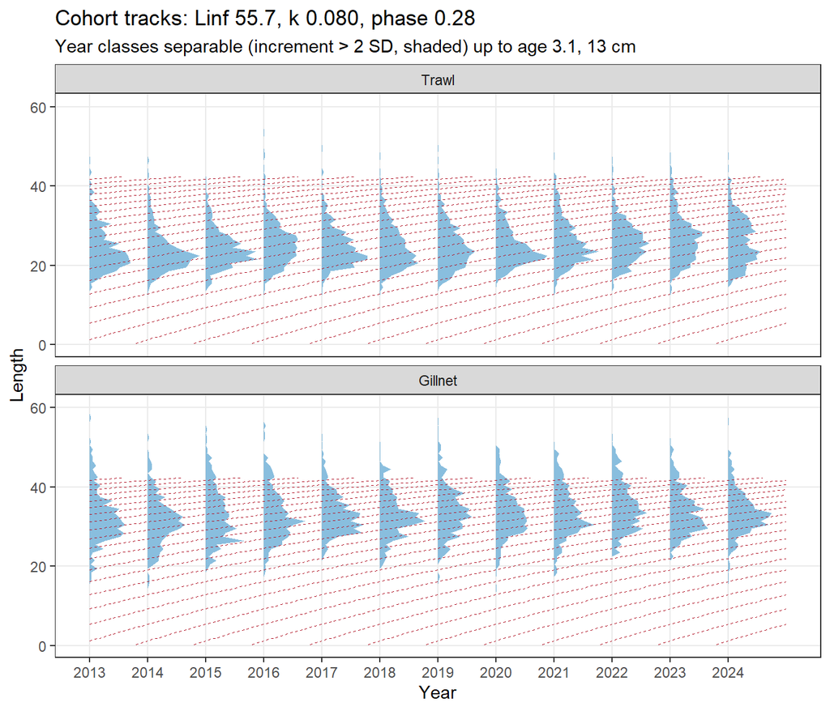

```r
plot_growth_lfd(gph)
```

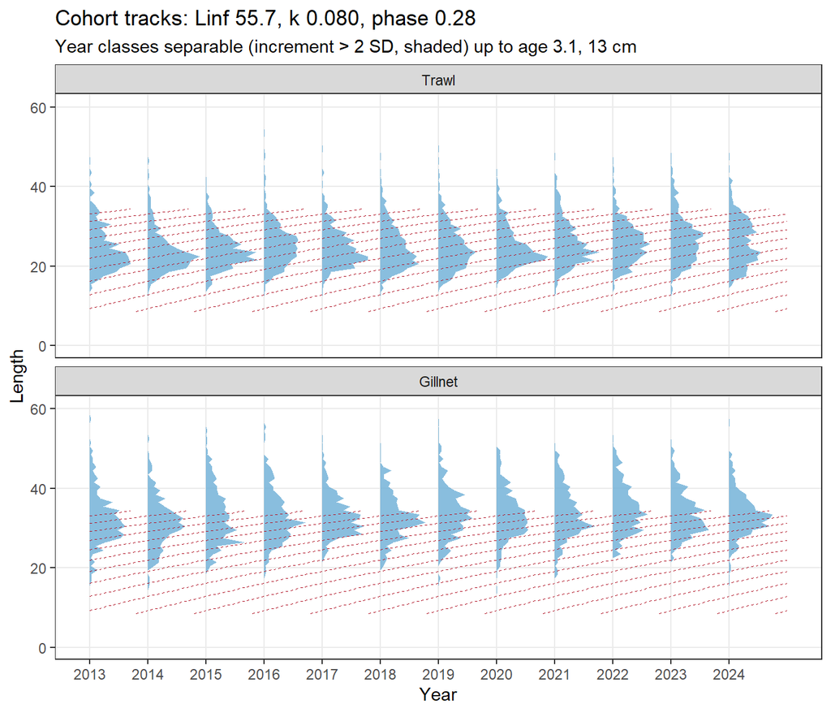

```r
plot_growth_lfd(gph, ages = c(2, 12))     # selected ages only
```

For alfonsino the profile is flat (it varies by only 1.5 log-likelihood units over the phase): with k = 0.08 the fish grow about 2-3 cm a year at the lengths caught, less than the spread of length at age, so year classes cannot be followed in the compositions: they are separable (shaded bands) only at lengths below those caught, and at the lengths caught the tracks run closer together than the width of a year class. The data neither support nor contradict the growth parameters here, and the t0 candidates are not informative. For fast-growing species with seasonal recruitment, sampled over a short period of the year, the modes are separate and the profile has a clear peak. Simulated compositions of such a species (k = 0.25, recruitment once a year, year-class strength varying at random) show what this looks like: the modes follow the tracks from year to year, and the phase is recovered (simulated: 0.35):

```r
set.seed(3)
L <- 0:60
lfd_sim <- FLQuants(Sim = FLQuant(0, dimnames = list(len = L, year = 2001:2006)))
for (y in 2001:2006) {
  mu <- 50 * (1 - exp(-0.25 * (0:12 + 0.35)))                   # mean length at age
  s  <- sqrt((0.08 * mu)^2 + 1)
  w  <- exp(-0.4 * (0:12)) * exp(rnorm(13, 0, 0.5))             # year classes
  p  <- sapply(seq_along(mu), function(j) pnorm(L + 1, mu[j], s[j]) - pnorm(L, mu[j], s[j])) %*% w
  lfd_sim$Sim[, as.character(y)] <- rmultinom(1, 2000, p)
}
gph_sim <- growth_phase_flicc(FLPar(linf = 50, k = 0.25, M = 0.3, L50 = 30), lfd = lfd_sim,
                              CVL = 0.08, sd0 = 1)
gph_sim$best
```

```
#>       k phase    logLik dLL
#> 18 0.25  0.34 -3997.661   0
```

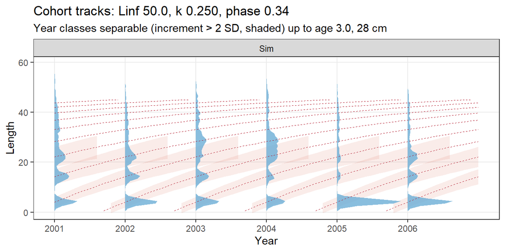

```r
plot_growth_lfd(gph_sim)
```

# 7 Selectivity

## 7.1 Functions and parameterisation

Selectivity is specified per gear in `sel_fun` and estimated on a scale relative to Linf (log parameters $\theta$), so starting values and priors are scale-free. With the estimated Linf:

**Logistic** (`"logistic"`):
$$S(L) = \left[1 + \exp\left(-\ln 19\,\frac{L - L_{50}}{L_{95} - L_{50}}\right)\right]^{-1},
\quad L_{50} = e^{\theta_1} L_\infty,\; L_{95} - L_{50} = e^{\theta_2} L_\infty .$$

**Double-sided normal** (`"dsnormal"`, dome):
$$S(L) = \exp\left[-\frac{(L - L_{mode})^2}{2\sigma^2}\right],\quad
\sigma = \begin{cases}\sigma_L & L < L_{mode}\\ \sigma_R & L \ge L_{mode}\end{cases},
\quad L_{mode} = e^{\theta_1}L_\infty,\; \sigma_L = e^{\theta_2}L_\infty,\; \sigma_R = e^{\theta_3}L_\infty .$$

**Normal** (`"normal"`): as above with $\sigma_L = \sigma_R$.

**Two size modes** (`"binormal"`, `"bidsnormal"`): for gears whose catch has two size groups, e.g. juveniles and adults in different seasons, or a gillnet fleet with two mesh groups. The selectivity is the sum of two curves, scaled to a maximum of 1:
$$S(L) = \frac{s(L)}{\max_L s(L)},\quad
s(L) = \exp\left[-\frac{(L - L_{1})^2}{2\sigma_1^2}\right]
+ h\,\exp\left[-\frac{(L - L_{2})^2}{2\sigma_2^2}\right],$$
with the first mode $L_1$ (`mode1`, SD `sd1`), the second mode $L_2 > L_1$ (`mode2`) and $h$ (`h`), the height of the second curve relative to the first. `"binormal"` uses one SD for the second curve (`sd2`); `"bidsnormal"` makes it double-sided (`lsd2` to the left, `rsd2` to the right of $L_2$), so the right limb of the large-fish mode can be domed or, with `rsd2 = 1000` fixed, flat. These functions have five and six parameters and need enough data in both modes: with few samples the second curve can degenerate (e.g. a vertical step).

Starting values: the mode (or L50) at the gear’s observed modal length, spreads of 0.1 Linf. Selectivity is evaluated at bin mid-points and is constant over time.

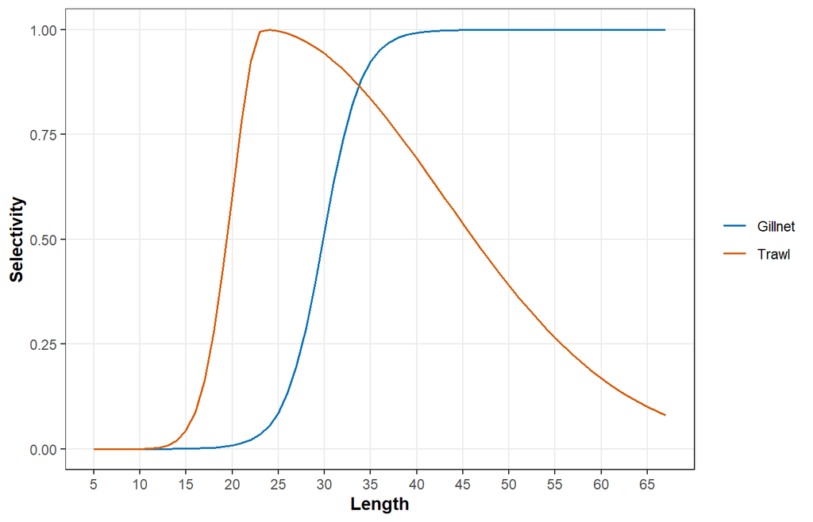

```r
plot_sel(fit)
```

```r
selpars_flicc(fit)
```

```
#> An object of class "FLPars"
#> [[1]]
#> An object of class "FLPar"
#> params
#>  mode   lsd   rsd
#> 23.83  3.33 19.44
#> units:  cm
#>
#> [[2]]
#> An object of class "FLPar"
#> params
#> SL50 SL95
#> 30.4 36.4
#> units:  cm
#>
#> Slot "names":
#> [1] "Trawl"   "Gillnet"
#>
#> Slot "desc":
#> character(0)
#>
#> Slot "lock":
#> [1] FALSE
```

## 7.2 Fixing selectivity parameters

`sel_fixed` fixes parameters on the length scale by gear, e.g. from mesh experiments:

```r
fiticc(lfd, stklen, sel_fun = sel_fun, catch_by_gear = cbg,
       settings = list(CVL = 0.1, obs_model = "dm", dm_theta = "saturating"),
       sel_fixed = list(Gillnet = list(SL50 = 30, SL95 = 34)))   # logistic
# dsnormal: list(mode = 24, lsd = 3, rsd = 1000)  (rsd = 1000: flat right limb)
# normal:   list(mode = 24, sd = 4)
# binormal:   list(mode1 = 15, sd1 = 2, mode2 = 30, sd2 = 5, h = 0.5)
# bidsnormal: list(mode1 = 15, sd1 = 2, mode2 = 30, lsd2 = 4, rsd2 = 1000, h = 0.5)
```

## 7.3 Exploring selectivity shapes

`plot_selfun()` draws a selectivity function for a range of parameter values, over the observed composition of a gear and with reference lengths. It helps to choose values for `sel_fixed` and the dome scenarios below:

```r
gn <- lfd[["Gillnet"]]
Lmid_g <- as.numeric(dimnames(gn)$len) + 0.5
Lmean_g <- round(sum(Lmid_g * apply(gn, 1, sum)) / sum(gn), 1)
Lmean_g
```

```
#> [1] 33.3
```

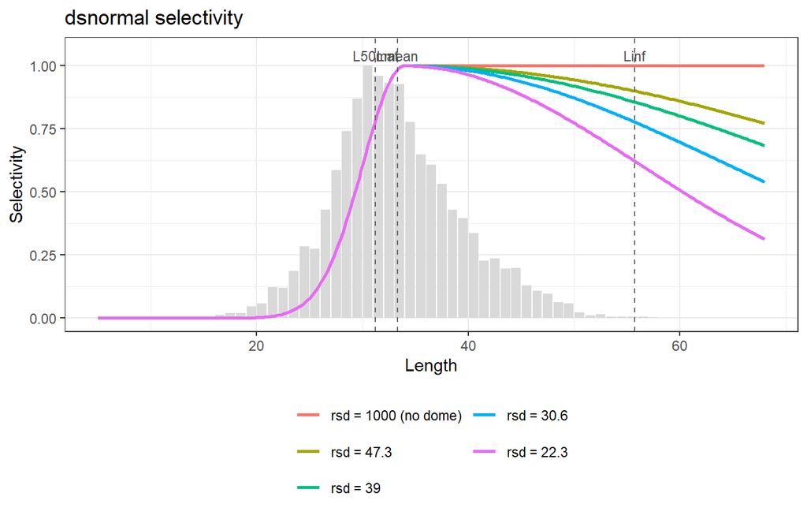

```r
ref_L <- c(L50mat = 31.2, Lmean = Lmean_g, Linf = 55.7)
plot_selfun("dsnormal", list(mode = 34, lsd = 4, rsd = c(1000, round(c(0.85, 0.7, 0.55, 0.4) * 55.7, 1))),
            lfd = gn, ref = ref_L)
```

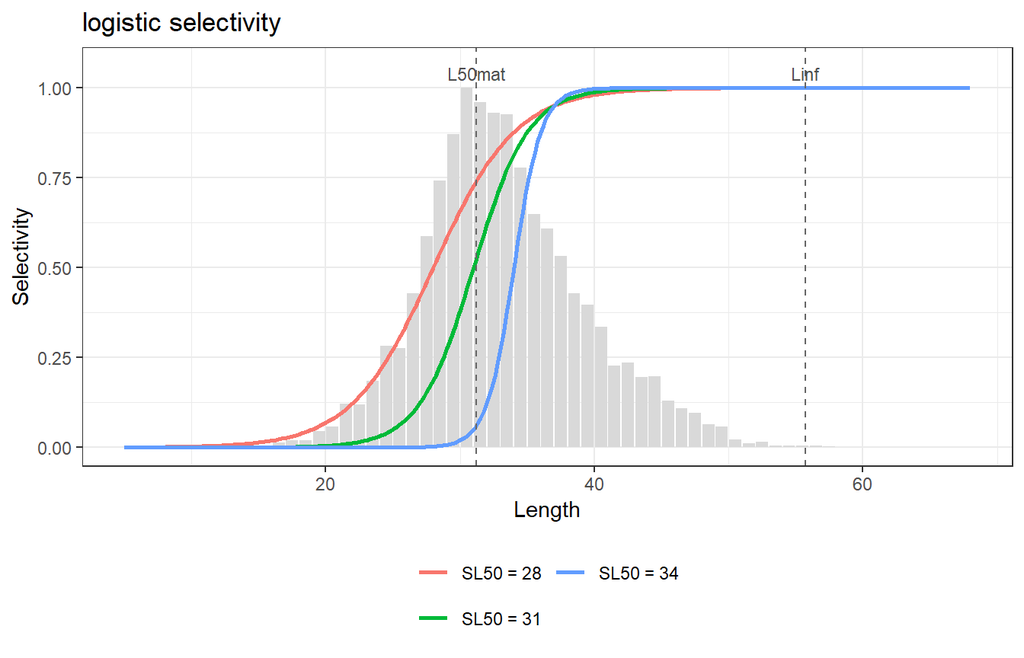

```r
plot_selfun("logistic", list(SL50 = c(28, 31, 34), SL95 = 37), lfd = gn, ref = ref_L[c(1,3)])
```

A double-sided normal with a very large right-hand SD (`rsd = 1000`) has a flat right limb, i.e. no dome; smaller values give increasing doming. The values shown, `c(1000, 0.85, 0.7, 0.55, 0.4) x Linf`, are the default levels of the dome sensitivity below, from no dome to a moderate one. `sel_curve_flicc()` returns the values of a curve.

The two-mode functions are explored the same way. A composition with two size modes arises, for example, when the gears are pooled into one fleet. `combine_lfd()` pools the gears, each raised by its catch share (for this example by weight, `cbg` = 70% trawl, 30% gillnet), and rescales the result to an effective sample size:

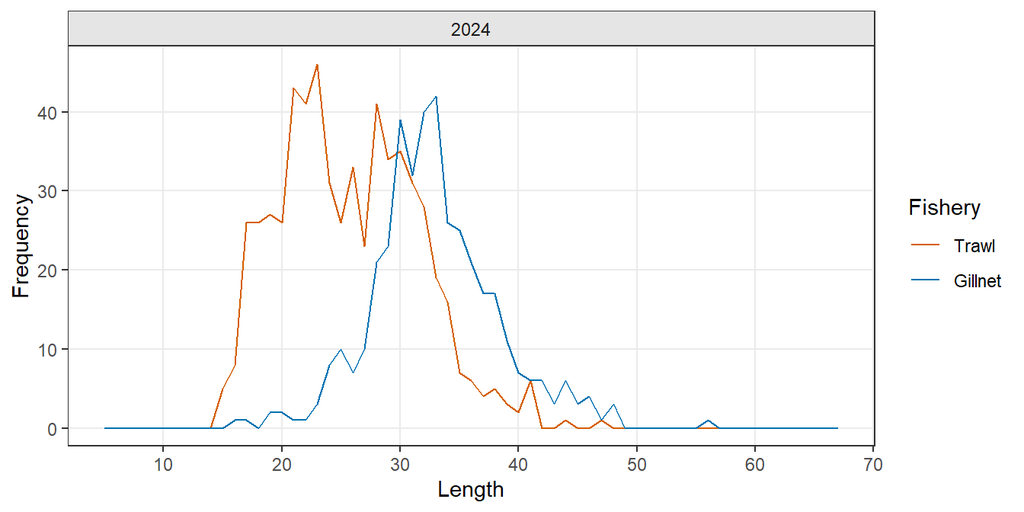

```r
yr_last  <- tail(as.numeric(dimnames(lfd[[1]])$year), 1)
lfd_fleet <- combine_lfd(window(lfd, start = yr_last), catch_by_gear = c(0.7,0.3) ,
                         lhpar = lhpar, ess.n = 500)
plot_lfd(window(lfd, start = yr_last))
```

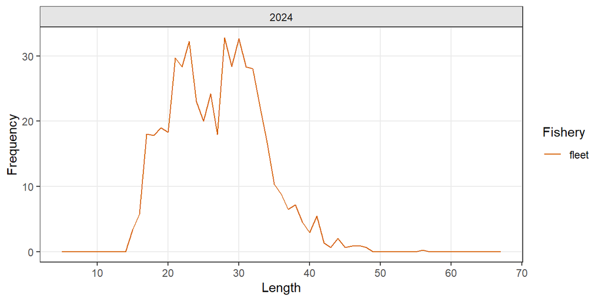

```r
plot_lfd(lfd_fleet)
```

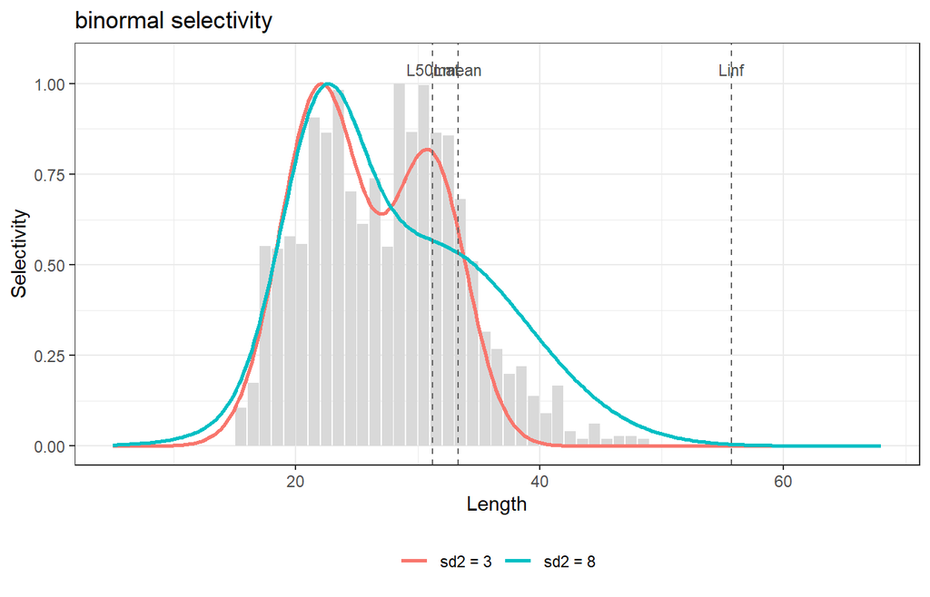

```r
plot_selfun("binormal", list(mode1 = 22, sd1 = 3.3, mode2 = 31, sd2 = c(3, 8), h = 0.8),
            lfd = lfd_fleet, ref = ref_L)
```

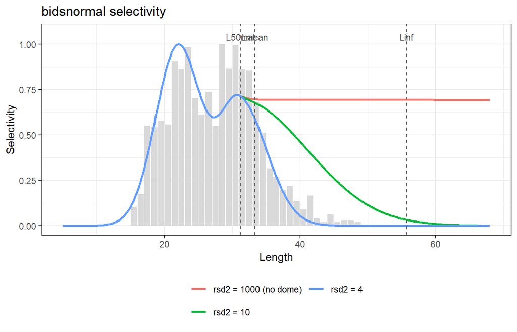

```r
plot_selfun("bidsnormal", list(mode1 = 22, sd1 = 3.3, mode2 = 31, lsd2 = 3,
                               rsd2 = c(1000, 10, 4), h = 0.7),
            lfd = lfd_fleet, ref = ref_L)
```

These curves are fitted to the pooled fleet in section *Sensitivity runs and ensembles: a single year*.

## 7.4 Gear selectivity, availability and population selectivity

The selectivity $S_g(L)$ that FLicc estimates for a gear is not the selectivity of the gear itself (its contact or mesh selectivity) but the **population selectivity**: the relative fishing mortality at length for the stock as a whole, which combines the gear’s contact selectivity with the availability of fish of each size to where the fleet fishes. Sampson and Scott (2011) showed with a spatial model of linked subpopulations that population selectivity becomes dome-shaped even when every subpopulation is fished with the same asymptotic gear, unless fishing mortality is uniform across them: older fish accumulate in less-fished areas, a “cryptic biomass” that escapes capture. The shape depends on the gear, the level and spatial distribution of fishing effort, and the movement of fish between areas.

Consequences for FLicc:

- **A logistic gear does not imply logistic population selectivity.** The question is whether the fleet’s fishing mortality reaches the large fish in proportion, not only what the mesh or hook does.
- **Slight doming is a plausible state of nature**, particularly where large fish move deeper, offshore or into areas that are fished less. This is the rationale for running the dome sensitivity routinely (next section) and, where the doming level is uncertain, for integrating it with `ensemble_flicc()`.
- **The dome is an assumption about fish that are not seen.** A fitted dome tells the model that large fish are present but not caught, so they continue to grow and spawn, and SPR increases. That is right if they are in a refuge, and optimistic if they are missing because they died (higher F or natural mortality of large fish). Length data alone cannot separate the two, and a better likelihood for a stronger dome is not evidence that the cryptic biomass exists; the doming level should be informed by knowledge of the fishery and the stock’s distribution.
- **Data by area can be used as separate gears** (“areas as fleets”): each area then has its own selectivity, which removes the part of the dome that comes from mixing areas with different size compositions.
- **The tail cut** conditions on the fish below the cut and so reduces the dependence on the assumed dome, which acts on the largest fish.
- Because population selectivity depends on where and how hard the fleet fishes, it can change when the effort distribution changes substantially. With a stable fishery a constant selectivity is a reasonable assumption; a change of sign of the residuals between periods (section *Residual diagnostics*) is the signal to check.

| Situation | Population selectivity | In FLicc |
| --- | --- | --- |
| Fleet covers the stock’s range evenly, or fish mix well | close to gear selectivity | logistic base; dome sensitivity as a check |
| Fishing concentrated where small and mid-sized fish are; large fish less available | dome plausible | dome sensitivity; ensemble over mild to moderate domes or tail cut |
| Length data available by area | dome partly from the mix of areas | areas as separate gears |
| Substantial change in where or how the fleet fishes | may change | check residuals by period; `by_year` |

*Reference*: Sampson, D.B. and Scott, R.D. (2011). A spatial model for fishery age-selection at the population level. *Canadian Journal of Fisheries and Aquatic Sciences*. doi:10.1139/f2011-044.

## 7.5 Dome sensitivity: a recommended standard run

Slight doming (large fish less selected or less available) is hard to detect from length data, and an unmodelled dome is read as higher F. A sensitivity over fixed dome shapes is therefore recommended for every gear assumed logistic. `dome_sens_flicc()` refits the model with that gear as a double-sided normal whose right-hand SD is fixed at a sequence of values (default `c(1000, 0.85, 0.7, 0.55, 0.4) x Linf`, from a flat right limb to a moderate dome in even steps; stronger domes can be given with `rsd`); the mode and left-hand SD are estimated, all other settings and data as in the base fit.

```r
ds <- dome_sens_flicc(fit, gear = "Gillnet")
ds$table
```

```
#>   scenario    rsd conv    logLik      AIC SPR_last   Fspr Fap_last  dAIC
#> 1     base     NA    0 -36979.56 74021.12    0.166 0.0900   0.1950  0.00
#> 2  rsd1000 1000.0    0 -36986.52 74035.05    0.165 0.0895   0.1950 13.93
#> 3  rsd47.3   47.3    0 -36985.87 74033.75    0.169 0.0906   0.1935 12.63
#> 4    rsd39   39.0    0 -36985.55 74033.10    0.171 0.0911   0.1927 11.98
#> 5  rsd30.6   30.6    0 -36984.89 74031.77    0.176 0.0923   0.1910 10.65
#> 6  rsd22.3   22.3    0 -36983.16 74028.33    0.189 0.0952   0.1864  7.21
```

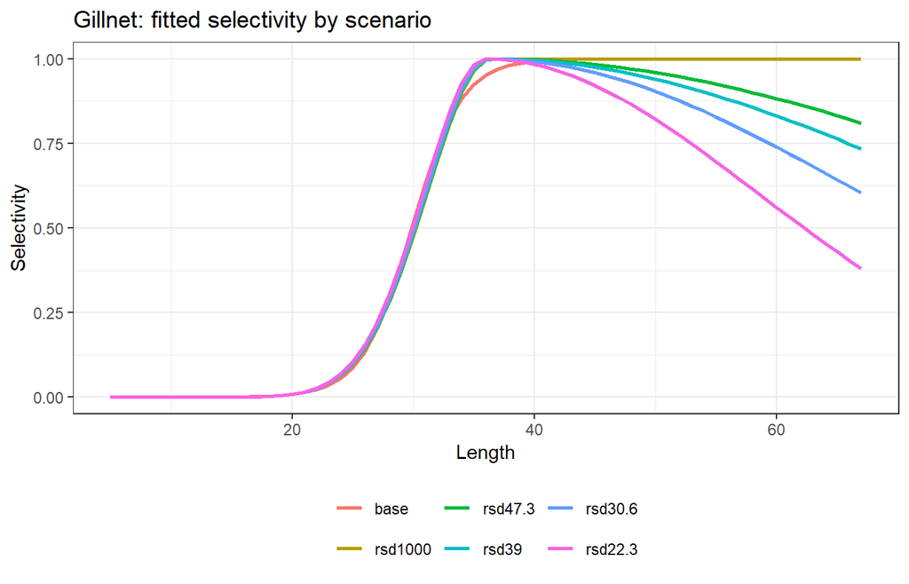

```r
plot_dome_sens(ds)
```

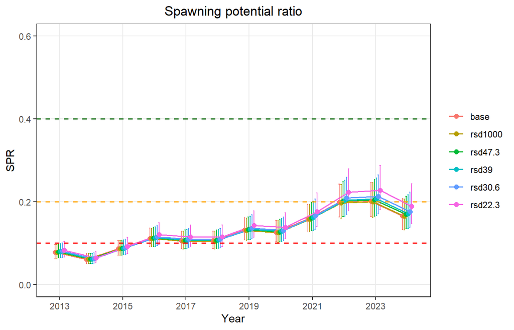

```r
plot_dome_sens(ds, "spr", ci = TRUE)
```

```r
fit_cut_sel <- fiticc(lfd, stklen, sel_fun = sel_fun, catch_by_gear = cbg,
                     settings = list(CVL = 0.1, obs_model = "dm", dm_theta = "saturating", tail_cut = 47))
ds_cut <- dome_sens_flicc(fit_cut_sel, gear = "Gillnet", se = FALSE)
data.frame(scenario = ds$table$scenario, SPR_no_cut = ds$table$SPR_last,
           SPR_cut47 = ds_cut$table$SPR_last)
```

```
#>   scenario SPR_no_cut SPR_cut47
#> 1     base      0.166     0.247
#> 2  rsd1000      0.165     0.265
#> 3  rsd47.3      0.169     0.274
#> 4    rsd39      0.171     0.279
#> 5  rsd30.6      0.176     0.288
#> 6  rsd22.3      0.189     0.310
```

**Integrating the dome levels.** Instead of reporting the dome levels side by side, they can be combined into one estimate with `ensemble_flicc()`. For each year the ensemble is the mixture of the members’ distributions of log SPR, $\sum_i w_i\,N(\mu_i, se_i^2)$; its variance is the within-fit part $\sum_i w_i se_i^2$ plus the between-fit part $\sum_i w_i(\mu_i-\bar\mu)^2$, and the median and interval are quantiles of the mixture. Equal weights are the natural choice for assumptions the data cannot distinguish; Akaike weights (`weights = "aic"`) are only allowed when all members use the same data and likelihood, which holds for the dome levels but not, for example, across tail cuts.

```r
ens <- ensemble_flicc(ds$fits[-1])     # the five dome levels, equal weights
ens$members
```

```
#>      name weight      AIC dAIC SPR_last se_log_last
#> 1 rsd1000    0.2 74035.05 6.72    0.165       0.115
#> 2 rsd47.3    0.2 74033.75 5.42    0.169       0.118
#> 3   rsd39    0.2 74033.10 4.77    0.171       0.119
#> 4 rsd30.6    0.2 74031.77 3.44    0.176       0.122
#> 5 rsd22.3    0.2 74028.33 0.00    0.189       0.129
```

```r
tail(ens$table[, c("year", "spr", "lwr", "upr", "sd_within", "sd_between")], 3)
```

```
#>    year       spr       lwr       upr sd_within sd_between
#> 10 2022 0.2063425 0.1654505 0.2614319 0.1083785 0.04284013
#> 11 2023 0.2097350 0.1672355 0.2678229 0.1109220 0.04559810
#> 12 2024 0.1734329 0.1358433 0.2256820 0.1207019 0.04620789
```

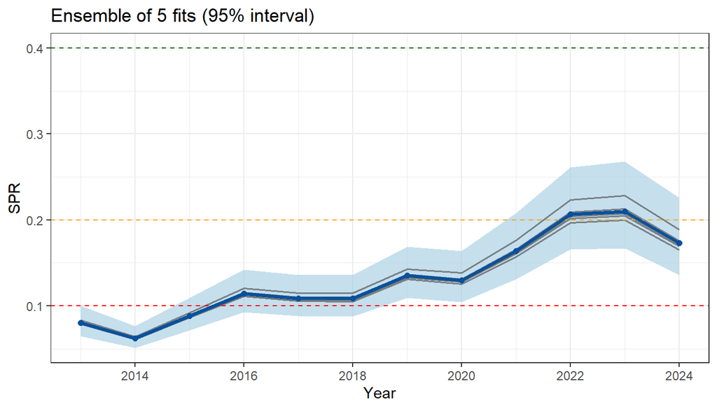

```r
plot_ensemble_flicc(ens)
```

The sensitivity is meant for gears assumed asymptotic. For a gear already fitted as a dome (here the trawl, estimated right-hand SD about 19.4 cm), fixing a wide right-hand SD forces a shape the data reject, which shows as very large dAIC.

## 7.6 Comparing selectivity functions

`plot_compare_sel()` draws the fitted selectivity of a list of fits, one panel per gear and one colour per fit. The example refits the reference model with four selectivity functions for the gillnet, keeping the trawl as a double-sided normal: logistic; double-sided normal with the right-hand SD fixed at 1000 (a flat right limb, close to the logistic in shape); normal (a symmetric dome); and double-sided normal with both SDs estimated. The vectors `gill_fun` and `gill_fix` hold the gillnet function and the fixed parameters of each run, and `Map()` fits one model per pair.

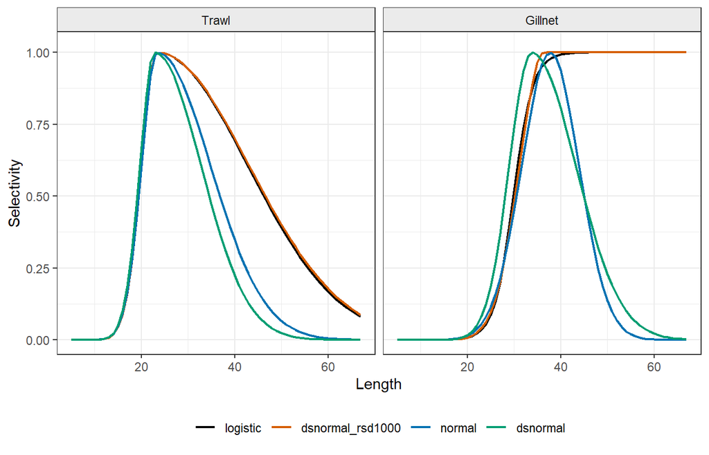

```r
gill_fun <- c(logistic = "logistic", dsnormal_rsd1000 = "dsnormal",
              normal = "normal", dsnormal = "dsnormal")
gill_fix <- list(NULL, list(rsd = 1000), NULL, NULL)
fits_sel <- Map(function(fun, fix) {
  fiticc(lfd, stklen, sel_fun = c("dsnormal", fun), catch_by_gear = cbg,
         sel_fixed = if (is.null(fix)) NULL else list(Gillnet = fix),
         settings = list(CVL = 0.1, obs_model = "dm", dm_theta = "saturating"))
}, gill_fun, gill_fix)
plot_compare_sel(fits_sel)
```

```r
sel_tab <- data.frame(fit = names(fits_sel),
                      AIC = sapply(fits_sel, function(f) round(AIC(LLflicc(f)), 1)),
                      SPR_last = sapply(fits_sel, function(f) round(sprcur_flicc(f), 3)),
                      row.names = NULL)
sel_tab$dAIC <- sel_tab$AIC - min(sel_tab$AIC)
sel_tab
```

```
#>                fit     AIC SPR_last  dAIC
#> 1         logistic 74021.1    0.166  42.5
#> 2 dsnormal_rsd1000 74035.0    0.165  56.4
#> 3           normal 74105.5    0.369 126.9
#> 4         dsnormal 73978.6    0.639   0.0
```

The trawl panel shows how far the trawl estimate moves when only the gillnet shape changes. Over the four gillnet functions the last-year SPR ranges from 0.165 to 0.639, with dAIC from 0 to 126.9. As with the dome sensitivity, read the comparison together with gear knowledge: a better fit for a dome does not show that large fish are less selected, because a shortage of large fish can also come from F.

## 7.7 Choosing selectivity

- Use logistic unless gear knowledge (gillnet mesh, hook size, availability of large fish) supports a dome.
- A dome fitted without support absorbs a shortage of large fish that may come from F; SPR then becomes optimistic.
- Several gears sampling different length ranges make domes more identifiable.
- A tail cut (section *Tail of the length composition*) reduces the cost of an unmodelled mild dome (*simulation*: a strong dome fitted as logistic, -17% bias in SPR; with a cut at 0.8 Linf, +1%).
- Always run the dome sensitivity for gears assumed logistic, and report it.

## 7.8 Check 6: selectivity plausibility

| **Look for** | Ascending limbs consistent with the gear and the left limb of the compositions; domes only where expected. |
| --- | --- |
| **Red flags** | Very narrow domes; $\sigma_R$ at very small values for a gear expected to be logistic; L50 below the smallest sampled fish. |
| **Action** | Compare logistic and dome by AIC and by status; fix parameters from external information; use a tail cut. |

# 8 Fitting and fit checks

## 8.1 The model in brief

For each gear $g$ and year $y$, fishing mortality at length is the gear’s F times its selectivity, $F_{g,y}(L) = F_{g,y}S_g(L)$, and total mortality is $Z_y(L) = M(L) + \sum_g F_{g,y}(L)$. Fish grow through the length bins following von Bertalanffy growth, with variation in Linf among fish; the expected length composition of each gear’s catch follows from the numbers surviving to each length and the gear’s F. Each year is fitted as an equilibrium at that year’s F, with F linked between years by a random walk and selectivity shared by all years. Status is the spawning potential ratio,
$$\mathrm{SPR}_y = \frac{\sum_L N_{F_y}(L) W(L) P_{mat}(L)}{\sum_L N_0(L) W(L) P_{mat}(L)} ,$$
the spawning output per recruit at the year’s F relative to the unfished state. The equations are in section *Model equations and comparison of models*.

## 8.2 Fitting the reference model

```r
system.time(fiticc(lfd, stklen, sel_fun = sel_fun, catch_by_gear = cbg,
                   settings = list(CVL = 0.1, obs_model = "dm", dm_theta = "saturating")))
```

```
#>    user  system elapsed
#>    0.24    0.00    1.41
```

```r
sigmaF_flicc(fit)
```

```
#> [1] 0.3
```

```r
neff_flicc(fit)[1:4, ]
```

```
#>    gear year   n   alpha0     neff
#> 1 Trawl 2013 600 790.3777 341.5091
#> 2 Trawl 2014 600 790.3777 341.5091
#> 3 Trawl 2015 600 790.3777 341.5091
#> 4 Trawl 2016 600 790.3777 341.5091
```

## 8.3 Settings

| Setting | Default | Role |
| --- | --- | --- |
| `pop_model` | `"gtg"` | `"gtg"`, `"gamma"` (`"gtg.dyn"`: development) |
| `obs_model` | `"dm"` | `"dm"`, `"mn"`, `"nb"` |
| `dm_theta` | `"saturating"` | DM precision: estimated (`"saturating"`, `"linear"`) or `"fixed"` |
| `CVL` | 0.1 | CV of Linf among growth groups (fixed unless `CVL.sd`) |
| `ngtg`, `maxsd` | 13, 3 | GTG grid (LBSPR: 13, 2) |
| `Mpow` | 0 | M/k at length $\propto (L_\infty/L)^{Mpow}$ |
| `linf.sd`, `Mk.sd`, `CVL.sd` | `NULL` | estimate with a prior around the input |
| `sigmaF` | 0.3 | random-walk SD of log F, fixed |
| `prior_sigmaF` | – | `c(mean, sd, use)`: estimate sigmaF with a prior; `FALSE`: no random walk |
| `F_re` | `FALSE` | log F as random effects (Laplace), sigmaF estimated |
| `catch.sd` | 0.05 | SD of the catch-share constraint |
| `tail_cut` | `NULL` | exclude bins with lower bound `>= tail_cut` (length) |
| `Lplus` | `NULL` | pool bins with lower bound `>= Lplus` |
| `rob_eps` | 0 | robust likelihood: $(1 - \epsilon)\pi + \epsilon/n_{bins}$ |
| `spr_ref` | 40 | SPR target(s) (%) whose Fspr is stored with the fit |
| `FM_min`, `FM_max` | 0.05, 4 | bounds on apical F/M (soft penalty) |
| `tail_warning` | `FALSE` | warn about fish beyond the largest GTG Linf |

Further arguments of `fiticc()`: `n_restart` (restarts while the gradient is large), `se = FALSE` (skip standard errors), `start` (e.g. `fit$opt$par`), `years`, `by_year`, `sel_fixed`.

## 8.4 Check 7: convergence

```r
flicc_convergence(fit)
```

```
#>                              check              value passed
#> 2           Gradient is acceptable          5.704e-05   TRUE
#> 3     Hessian is positive definite               TRUE   TRUE
#> 4        Standard errors available 31 / 31 parameters   TRUE
#> 5 Hessian eigenvalues are positive              14.22   TRUE
#> 6   Newton decrement is negligible           2.38e-13   TRUE
#> 7                          Overall                 ok   TRUE
#>                                                                                        interpretation
#> 2                                                             The fit is close to a stationary point.
#> 3                                                                The model curvature is well behaved.
#> 4                                                  Uncertainty could be estimated for all parameters.
#> 5                                             No flat or negative curvature directions were detected.
#> 6 Expected further gain in log-likelihood (0.5 g'H^-1 g) is below 0.001; NA without Newton polishing.
#> 7              ok: converged; warning: usable, but check the gradient or decrement; fail: do not use.
```

| **Pass** | convergence code 0, maximum gradient < 0.001-0.01, positive-definite Hessian, finite standard errors. |
| --- | --- |
| **Red flags** | large gradient after restarts; non-positive-definite Hessian; parameters at bounds (F/M at `FM_min`/`FM_max`, very small selectivity spreads). |
| **Action** | more restarts (`n_restart`); restart from `fit$opt$par`; simplify selectivity (logistic, fewer gears); check sample sizes; a tail cut or `rob_eps` if the tail drives the problem. |

## 8.5 Check 8: fit to the compositions

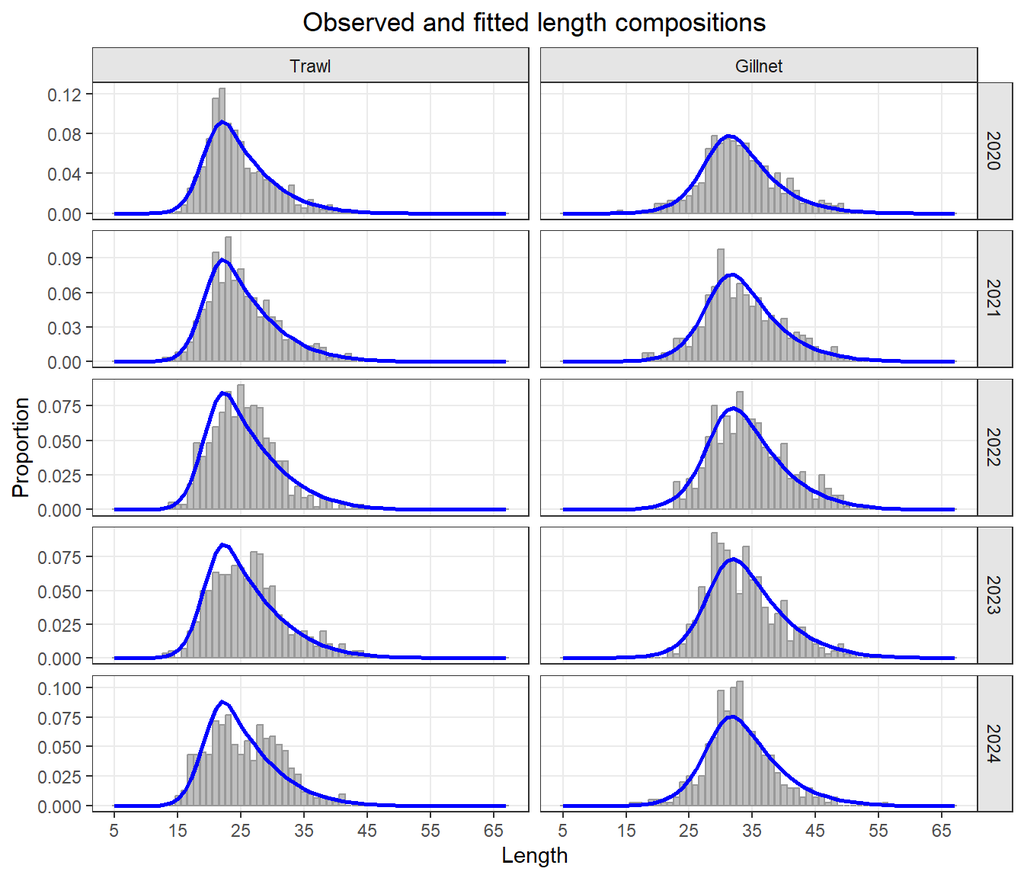

```r
plot_len(fit, by_gear = TRUE, year = 2020:2024)
```

[figure not shown]

| **Look for** | Predictions through the observed modes and descending limbs in every gear. |
| --- | --- |
| **Red flags** | Systematic misfit of the left limb (selectivity), of the tail (Linf, CVL, dome), or of one gear only; the misfit changing sign between periods (time-varying selectivity or sampling). |
| **Action** | Revisit selectivity form and Linf; tail cut; split periods. |

```r
plot_len(fit)
```